# google-trends-analysis

Schyuler Lujan

2/20/2021

# Overview of Project

We are looking at google trends data on college search terms to answer the following research question:

Among colleges that predominantly grant bachelor’s degrees, did it result in more student interest in high-earnings colleges relative to low-earnings ones (as proxied by Google searches for keywords associated with those colleges)?

For our data we are using the following:

- Google Trends index by college keyword from 3/24/2013 - 3/27/2016
- Data from College Scorecard, containing information about US colleges and their graduated students
- Linking table, to help us join the Google Trends data and College Scorecard data

# Data Cleanup

## Load Relevant Libraries

```r
# Load relevant libraries
library(tidyverse)
library(kableExtra)
library(vtable)
library(jtools)
library(stringr)
library(gridExtra)
library(purrr)
```

## Load Raw Data

list.files() with the pattern option to get a list of the trends_up_to_ files, and then read them in using a for() loop or (recommended) using map from the purrr package. In either case you will probably want to follow up with a bind_rows(). You can isolate the first ten characters of a variable x using str_sub(x,1,10). Just sayin’.

```r
# Set our working directory
setwd("C:/Users/The Crust Haggis/OneDrive - Seattle University/OMSBA/Year 02/02 - Winter 2021/ECON 5300 Applied Econometrics/06 - Projects/Google-Trends-Data-Exploration")

# Get our list of files
file_list <- list.files(path = './raw-data/', pattern = 'trends_up_to_', full.names = TRUE)

# Load the Google trends data
google_trends_raw_df <- file_list %>%
  map(read_csv) %>%
  bind_rows()

# Load the scorecard data
scorecard_raw_df <- read.csv("./raw-data/Most+Recent+Cohorts+(Scorecard+Elements).csv")

# Load the linking table
link_raw_df <- read.csv("./raw-data/id_name_link.csv")
```

## Linking Data Cleanup

```r
# Find if there are rows where schname is duplicated
link_df_duplicates <- data.frame(table(link_raw_df$schname)) %>%
  filter(Freq > 1) %>%
  rename(schname = Var1)

# Remove all rows where schname is duplicated using anti-join
link_df <- link_raw_df %>%
  anti_join(link_df_duplicates, by = "schname")

# Remove any null values from the data set
link_df <- na.omit(link_df)

# Rename our keys
link_df <- link_df %>%
  rename(UNITID = unitid,
         OPEID = opeid)

# Check that the UNITID is unique -- this is our join key
sum(duplicated(link_df$unitid))
```

```
## [1] 0
```

## Scorecard Data Cleanup

```r
# Select only the relevant variables
scorecard_df <- scorecard_raw_df %>%
  select(UNITID, OPEID, INSTNM, PREDDEG, md_earn_wne_p10.REPORTED.EARNINGS)

# Rename our earnings variable
scorecard_df <- scorecard_df %>%
  rename(median_earnings_p10 = md_earn_wne_p10.REPORTED.EARNINGS)

# Filter on PREDDEG to only show schools where PREDDEG == 3
# Remove schools where earnings info was suppressed due to privacy concerns
scorecard_df <- scorecard_df %>%
  filter(PREDDEG == 3,
         median_earnings_p10 != 'PrivacySuppressed') %>%
  select(-PREDDEG)

# Change our median_earnings_p10 variable from string to numeric
scorecard_df <- scorecard_df %>%
  mutate(median_earnings_p10 = as.numeric(median_earnings_p10))

# Remove null values from the data set
scorecard_df <- na.omit(scorecard_df)

# Check that the UNITID is unique -- this is our join key
sum(duplicated(scorecard_df$UNITID))
```

```
## [1] 0
```

## Google Trends Data Cleanup

In our analysis, the index will be our dependent variable. Indexes for keywords cannot be compared, so we must standardize the index within each keyword.

```r
# Remove nulls
google_trends_df <- google_trends_raw_df %>%
  na.omit(google_trends_df)

# Create our standardized index by keyword
google_trends_df <- google_trends_df %>%
  group_by(keyword) %>%
  mutate(std_index = (index - mean(index)) / sd(index) )
```

## Joining Tables

```r
# Join the link_df and scorecard_df with an inner join
join1_df <- link_df %>%
  inner_join(scorecard_df, by = "UNITID") %>%
  select(-OPEID.x) %>%
  rename(OPEID = OPEID.y)

# Join the join1_df with our google_trends_df
final_df <- join1_df %>%
  inner_join(google_trends_df, by = "schname") %>%
  select(-schname, -OPEID)
```

## Create Additional Variables

We will add some additional variables to better facilitate our analysis. The variables we will create are as follows:

- scorecard_published
- seasons (one each for winter, spring, summer, and fall)
- high_income

### Create scorecard published variable

Since we want to see if the scorecard had an effect on a college’s index, we will want to compare the effects before and after the scorecard was published. We will create a categorical variable that will take a value of 1 if the index occured after the scorecard was published, and a value of 0 if the variable occured before the scorecard was published

```r
# Cleanup of dates, duplicate month or week field and split column on " - "
# Convert the date fields from string to date format
final_df <- final_df %>%
  separate(monthorweek, c("begdate", "enddate"), " - ") %>%
  mutate(begdate = as.Date(begdate),
         enddate = as.Date(enddate))

# If the begdate falls before 9/1/15, it takes a value of 0; otherwise a value of 1
final_df <- final_df %>%
  mutate(scorecard_published = ifelse(begdate < as.Date("2015-09-01"), 0, 1),
         scorecard_published = as.factor(scorecard_published))
```

### Create seasons variables

Create four categorical variables for winter, spring, summer, and fall. This is to help us assess if there are any seasonal impacts, since the college application process is more prevalent at specific times of the calendar year.

```r
# Create dummy variables for seasons
final_df <- final_df %>%
  mutate(month = as.numeric(format(begdate, format = "%m")),
         winter = as.factor(ifelse(month < 4, 1, 0)),
         spring = as.factor(ifelse(month == 4 | month == 5 | month == 6, 1, 0)),
         summer = as.factor(ifelse(month == 7 | month == 8 | month == 9, 1, 0)),
         fall = as.factor(ifelse(month > 9, 1, 0))
  )

# Create a variable for season
final_df <- final_df %>%
  mutate(season = ifelse(winter == 1, 'winter',
                         ifelse(spring == 1, 'spring',
                                ifelse(summer == 1, 'summer', 'fall'))))

# Check if all colleges in our data set have data both before and after scorecard release
# If any colleges don't have data after the scorecard release, then remove them
check_before_after <- final_df %>%
  group_by(scorecard_published, INSTNM) %>%
  summarise(n = n()) %>%
  pivot_wider(names_from = scorecard_published, values_from = n)
```

### Create high income group variable

Additionally, we need to split our colleges into low and high income groups. For this, we will calculate the median income of the colleges in our data set. Any colleges that are above the median we will consider to be high income colleges. And any colleges below the median will be considered as low income colleges.

A categorical variable that will take the value of 1 if the school is in the high income group and 0 if it is in the low income group.

```r
# First, look at the median incomes for the colleges in our data set
median_earnings_df <- final_df %>%
  group_by(INSTNM, median_earnings_p10) %>%
  summarise(earnings = mean(median_earnings_p10))

# Calculate the overall median earnings for our data set
overall_median <- median(median_earnings_df$earnings)

# If the income is above the median, the college is considered high income and gets a value of 1
# Else, the college is considered low income and gets a value of 0
final_df <- final_df %>%
  mutate(high_income = ifelse(median_earnings_p10 > overall_median, 1, 0),
         high_income = as.factor(high_income))
```

### Summarise our data

```r
# Do our final grouping of our data by college and week
final_df <- final_df %>%
  group_by(INSTNM, begdate, median_earnings_p10, high_income, scorecard_published, season, winter, spring, summer, fall) %>%
  summarise(avg_std_index = mean(std_index))
```

```r
# Export our final df to a csv to be used in the final write-up
write_csv(final_df, path = 'final_df.csv')
```

# Exploratory Analysis - Univariate Analysis

We will be taking a closer look at each variable in our data set and taking note of any particular patterns.

## Summary Statistics

```r
summary(final_df)
```

```
##     INSTNM             begdate           median_earnings_p10 high_income
##  Length:277753      Min.   :2013-03-24   Min.   : 16700      0:139653
##  Class :character   1st Qu.:2013-12-29   1st Qu.: 35500      1:138100
##  Mode  :character   Median :2014-09-28   Median : 40900
##                     Mean   :2014-09-26   Mean   : 42476
##                     3rd Qu.:2015-06-28   3rd Qu.: 48100
##                     Max.   :2016-03-27   Max.   :166200
##  scorecard_published    season          winter     spring     summer
##  0:225424            Length:277753      0:208026   0:208411   0:208411
##  1: 52329            Class :character   1: 69727   1: 69342   1: 69342
##                      Mode  :character
##
##
##
##  fall       avg_std_index
##  0:208411   Min.   :-4.741365
##  1: 69342   1st Qu.:-0.491674
##             Median :-0.058272
##             Mean   : 0.000106
##             3rd Qu.: 0.421021
##             Max.   :10.452222
```

## Standardized Index

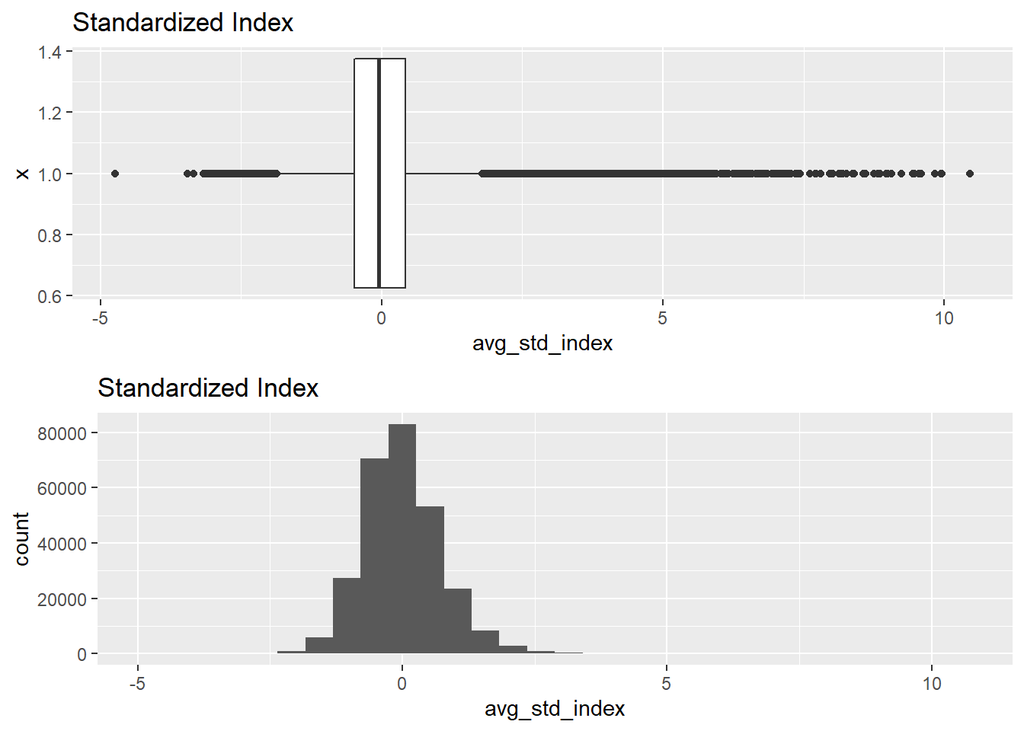

```r
# Create a boxplot and histogram for the index
grid.arrange(
ggplot(data = final_df,
       mapping = aes(x = 1,
                     y = avg_std_index)) +
  geom_boxplot() +
  ggtitle('Standardized Index') +
  coord_flip(),

ggplot(data = final_df,
       mapping = aes(x = avg_std_index)) +
  geom_histogram() +
  ggtitle('Standardized Index'),

ncol = 1)
```

## Median Earnings

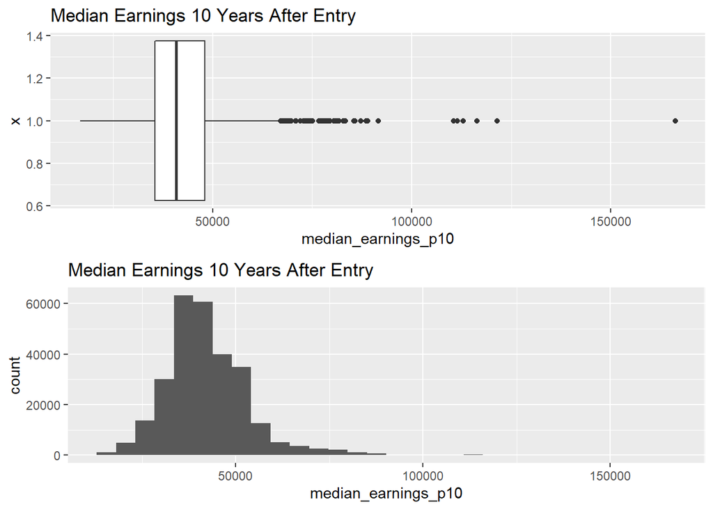

```r
# Create a boxplot and histogram for median earnings
grid.arrange(
ggplot(data = final_df,
       mapping = aes(x = 1,
                     y = median_earnings_p10)) +
  geom_boxplot() +
  ggtitle('Median Earnings 10 Years After Entry') +
  coord_flip(),

ggplot(data = final_df,
       mapping = aes(x = median_earnings_p10)) +
  geom_histogram() +
  ggtitle('Median Earnings 10 Years After Entry'),

ncol = 1)
```

## Scorecard Published

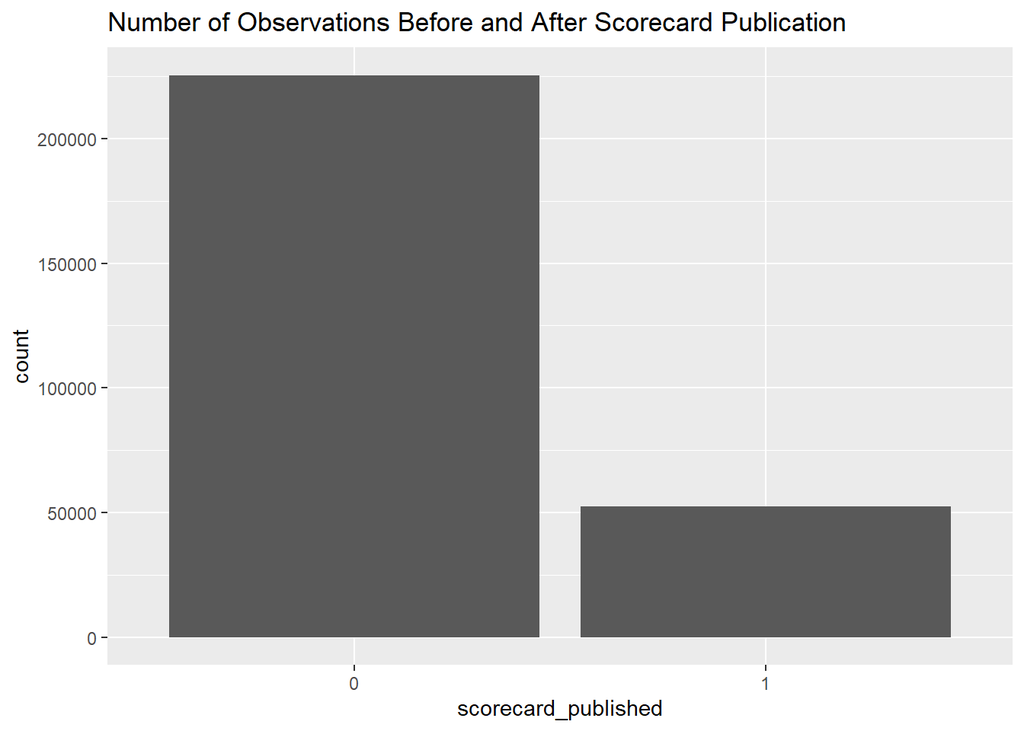

```r
# Create bar graph for scorecard published
ggplot(data = final_df,
       mapping = aes(x = scorecard_published)) +
  geom_bar() +
  ggtitle('Number of Observations Before and After Scorecard Publication')
```

Majority of our data set comes from before the scorecard was published.

# Exploratory Analysis - Multivariate Analysis

## Earnings and Standardized Index

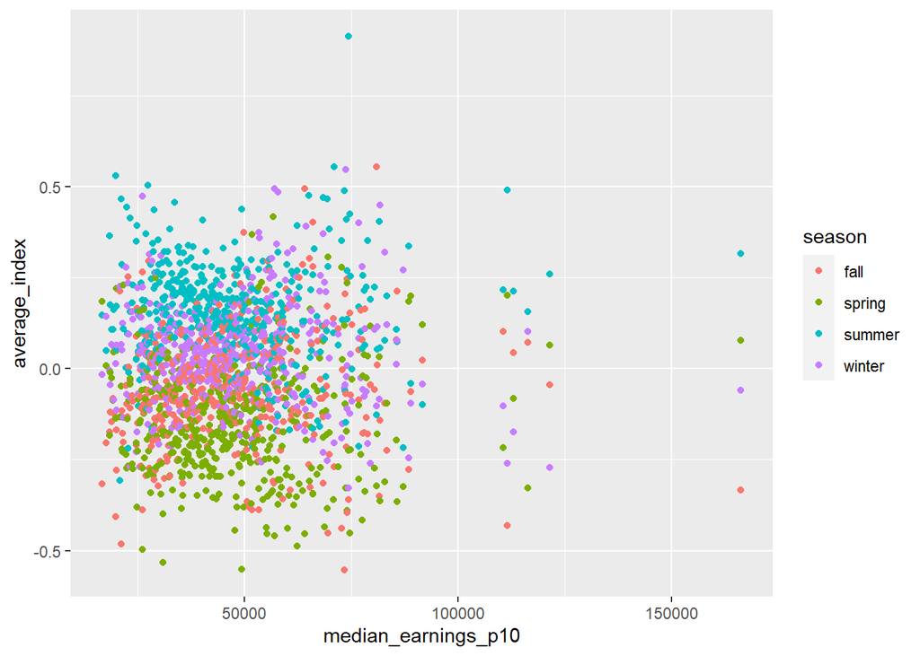

```r
# Assess any relationship between median earnings and average standardized index
final_df %>%
  group_by(median_earnings_p10, season) %>%
  summarise(average_index = mean(avg_std_index)) %>%
  ggplot(mapping = aes(x = median_earnings_p10, y = average_index, color = season)) +
  geom_point()
```

## Trends Over Time

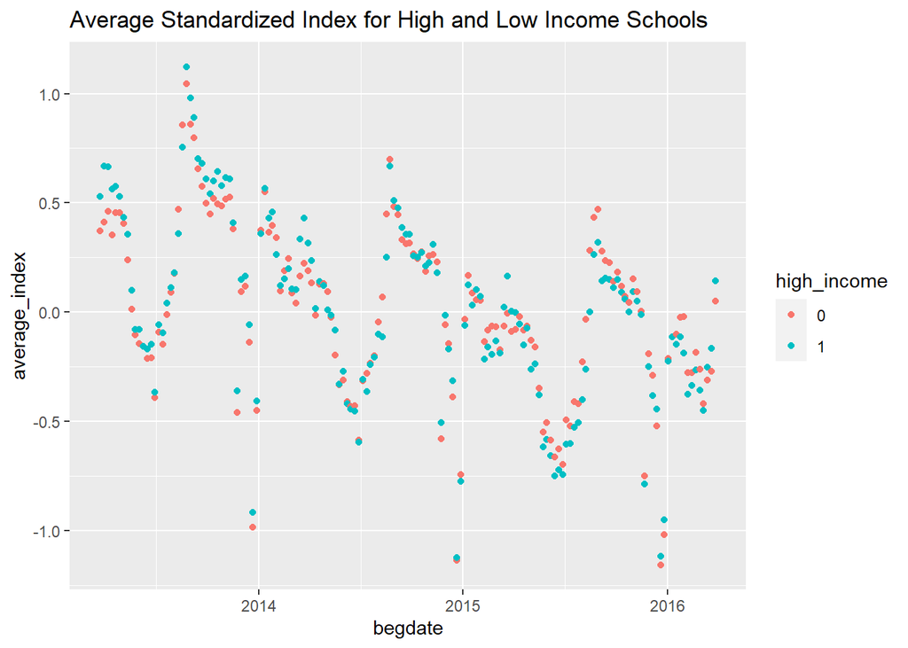

```r
# Look at high and low income over time, across all time periods
final_df %>%
  group_by(begdate, high_income) %>%
  summarise(average_index = mean(avg_std_index)) %>%
  ggplot(mapping = aes(x = begdate, y = average_index, color = high_income)) +
  geom_point() +
  ggtitle('Average Standardized Index for High and Low Income Schools')
```

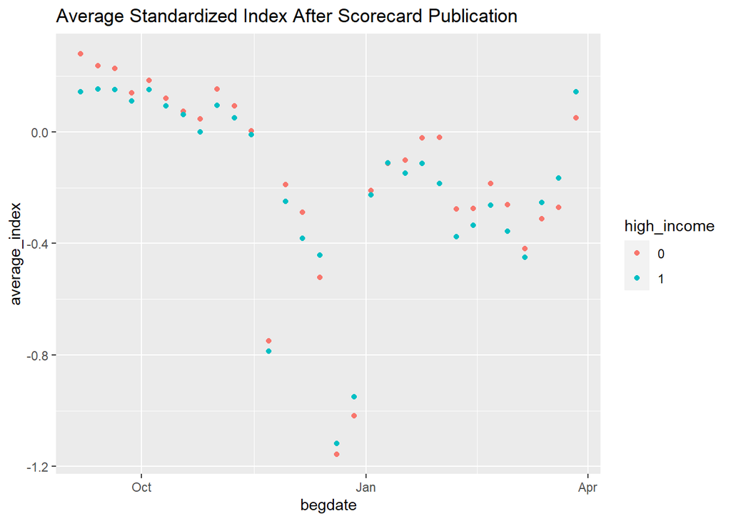

```r
# Look at high and low income over time, but only after 9/1/15
final_df %>%
  filter(scorecard_published == 1) %>%
  group_by(begdate, high_income) %>%
  summarise(average_index = mean(avg_std_index)) %>%
  ggplot(mapping = aes(x = begdate, y = average_index, color = high_income)) +
  geom_point() +
  ggtitle('Average Standardized Index After Scorecard Publication')
```

Additionally, there appears to be an overall downward trend after the publication of the scorecard. However, this may be due to a seasonal effect rather than just the scorecard itself.

## Seasons

Our scatterplot shows seasonal trends, so we will examine each season within a year more closely to see if we can find any notable differences.

```r
# Look at any overall seasonal differences
final_df %>%
  mutate(season = ifelse(winter == 1, 'winter',
                         ifelse(spring == 1, 'spring',
                                ifelse(summer == 1, 'summer', 'fall')))) %>%
  group_by(season) %>%
  summarise(average_index = mean(avg_std_index))
```

```
## # A tibble: 4 x 2
##   season average_index
##   <chr>          <dbl>
## 1 fall         -0.0657
## 2 spring       -0.137
## 3 summer        0.179
## 4 winter        0.0236
```

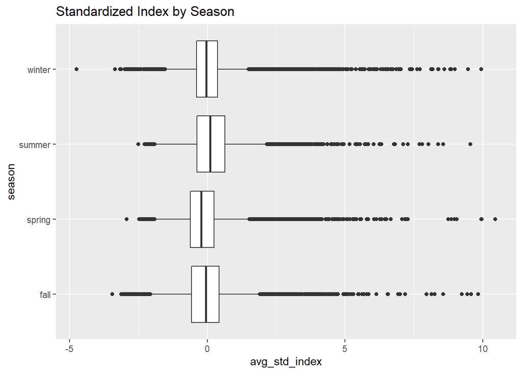

```r
# Compare boxplots by season
 final_df %>%
  mutate(season = ifelse(winter == 1, 'winter',
                         ifelse(spring == 1, 'spring',
                                ifelse(summer == 1, 'summer', 'fall')))) %>%
  group_by(season) %>%
  ggplot(mapping = aes(x = season, y = avg_std_index)) +
  geom_boxplot() +
  ggtitle('Standardized Index by Season') +
  coord_flip()
```

When looking at overall seasonal differences, summer has the highest average. It is possible that summer has the highest average because it is the season right before students start applying to colleges. Therefore, students may be looking up colleges more frequently in preparation for the college application cycle for fall and winter.

## Seasons and Earnings Level

Since there are clear seasonal differences, there might be pronounced seasonal differences according to the earnings level of the school.

```r
# To make groupsings easier, add a season variable to our dataframe
final_df <- final_df %>%
  mutate(season = ifelse(winter == 1, 'winter',
                         ifelse(spring == 1, 'spring',
                                ifelse(summer == 1, 'summer', 'fall'))))

# Look at any seasonal differences by earnings level
final_df %>%
  group_by(season, high_income) %>%
  summarise(average_index = mean(avg_std_index)) %>%
  pivot_wider(names_from = high_income, values_from = average_index)
```

```
## # A tibble: 4 x 3
## # Groups:   season [4]
##   season     `0`     `1`
##   <chr>    <dbl>   <dbl>
## 1 fall   -0.0773 -0.0539
## 2 spring -0.143  -0.130
## 3 summer  0.199   0.159
## 4 winter  0.0209  0.0264
```

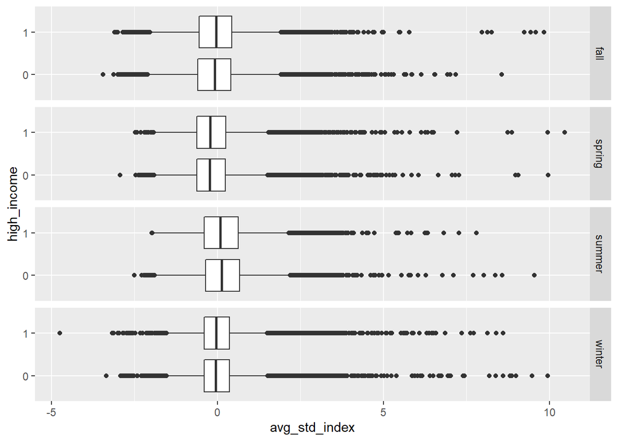

```r
# Compare boxplots by season and income level
 final_df %>%
  group_by(season, high_income) %>%
  ggplot(mapping = aes(x = high_income, y = avg_std_index)) +
  geom_boxplot() +
  coord_flip() +
  facet_grid(season ~.)
```

Again, summer shows the highest values for both high and low earnings schools. And the average standardized index is slightly higher for low-earnings colleges than for high-earnings colleges in summer.

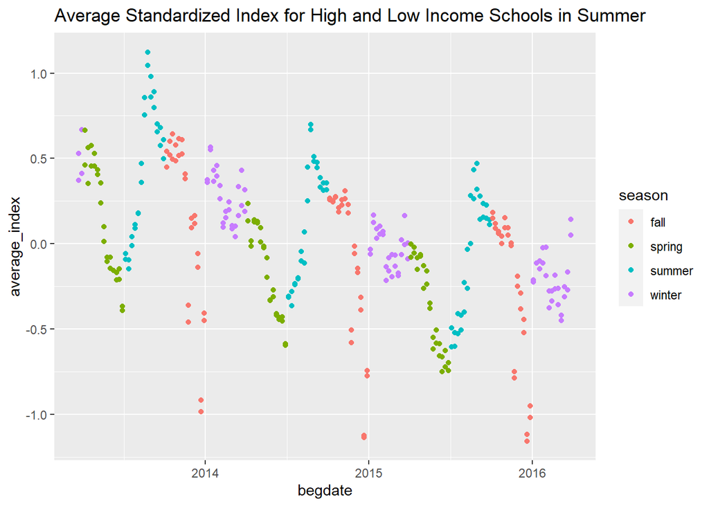

```r
# Look the scatterplot with colors by season
final_df %>%
  group_by(begdate, high_income, season) %>%
  summarise(average_index = mean(avg_std_index)) %>%
  ggplot(mapping = aes(x = begdate, y = average_index, color = season)) +
  geom_point() +
  ggtitle('Average Standardized Index for High and Low Income Schools in Summer')
```

Scatterplots by season reveal an upward trend in summertime for both high and low earnings colleges. All other seasons have a downward trend.

After exploratory analysis, the following appear to be likely:

- Being a high or low earnings college (on its own) does not appear to have any strong association with the standardized index
- Season (ie: fall, winter, spring, summer) appears to have a strong association with the average index, with summer being the time where all colleges are searched more often. However, within season there still don’t appear to be any pronounced differences between high and low earnings colleges
- Scorecard was published at the end of summer / beginning of fall. So any negative associations between the scorecard and the standardized index could be due to the seasonality, the scorecard, or a combination of both.

# Regression Model

```r
# First regression model with income and scorecard publication
reg1 <- lm(avg_std_index ~ high_income + scorecard_published, data = final_df)

# Second regression model including season variables
reg2 <- lm(avg_std_index ~ high_income + scorecard_published + summer, data = final_df)

# Third regression model, adding interaction term between scorecard and high income
reg3 <- lm(avg_std_index ~ high_income + scorecard_published + summer + scorecard_published*high_income, data = final_df)

# Fourth regression model, using fixed effects controlling for differences between seasons
reg4 <- lm(avg_std_index ~ high_income + scorecard_published + scorecard_published*high_income + summer + fall + spring, data = final_df)

# View all four models together and compare
export_summs(reg1, reg2, reg3, reg4)
```

|  | Model 1 | Model 2 | Model 3 | Model 4 |
| --- | --- | --- | --- | --- |
| (Intercept) | 0.04 *** | -0.02 *** | -0.02 *** | 0.10 *** |
|  | (0.00) | (0.00) | (0.00) | (0.00) |
| high_income1 | 0.00 | 0.00 | 0.01 ** | 0.01 ** |
|  | (0.00) | (0.00) | (0.00) | (0.00) |
| scorecard_published1 | -0.22 *** | -0.19 *** | -0.17 *** | -0.24 *** |
|  | (0.00) | (0.00) | (0.01) | (0.01) |
| summer1 |  | 0.22 *** | 0.22 *** | 0.10 *** |
|  |  | (0.00) | (0.00) | (0.00) |
| high_income1:scorecard_published1 |  |  | -0.05 *** | -0.05 *** |
|  |  |  | (0.01) | (0.01) |
| fall1 |  |  |  | -0.08 *** |
|  |  |  |  | (0.00) |
| spring1 |  |  |  | -0.24 *** |
|  |  |  |  | (0.00) |
| N | 277753 | 277753 | 277753 | 277753 |
| R2 | 0.01 | 0.03 | 0.03 | 0.04 |
| *** p < 0.001; ** p < 0.01; * p < 0.05. |  |  |  |  |